# Project: Visualizing FordGoBike Data By Karim Goudy

## Observation 8*

> **Any interesting relationships between the other features (not the main feature(s) of interest)?**

## Distribution of Age

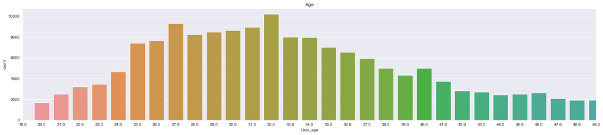

```python
# age
plt.figure(figsize = [25,5])
sb.countplot(data=df_clean, x='User_age');
plt.xlim((0,30));
plt.title("Age")
```

## Observation 9*

**As we can see, we have the largest density from ages 24 to 36, thus the plot has to be improved in explanatory analysis. However, she appears to be a bimodel. 32-year-old seems to like riding bikes the most. Marketing can target this demographic in order to enhance revenues.**

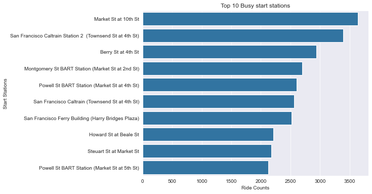

```python
plt.figure(figsize=(8,6))

# Top 10 peak start stations
counts_start = df.start_station_name.value_counts().nlargest(10)

# slice top 10 data
station_start = df.loc[df.start_station_name.isin(counts_start.index)]

# plot the stations
sb.countplot(data = station_start, y = 'start_station_name', color = no_color, order = counts_start.index);
plt.title('Top 10 Busy start stations')
plt.xlabel('Ride Counts')
plt.ylabel('Start Stations');
```

> Market St 10th St, San Francisco Caltrain Station 2 (Townsend St at 4th St), and Berry St at 4th St Buildings are the most popular commuter start stations.

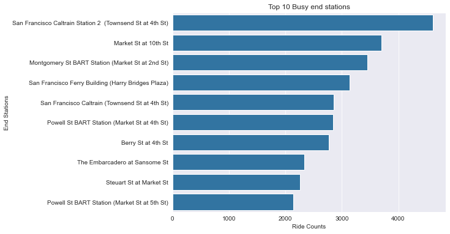

```python
plt.figure(figsize=(8,6))

# Top 10 peak end stations
counts_end = df.end_station_name.value_counts().nlargest(10)

# slice top 10 data
station_end = df.loc[df.end_station_name.isin(counts_end.index)]

# plot the stations
sb.countplot(data = station_end, y = 'end_station_name', color = no_color, order = counts_end.index)

# set title and label
plt.title('Top 10 Busy end stations')
plt.xlabel('Ride Counts')
plt.ylabel('End Stations');
```

## Bivariate Exploration

> Let us study and investigate connections between variables.

## Is there any relationship across customers and subscribers?

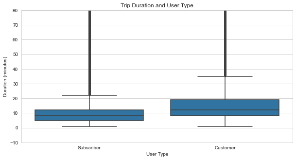

```python
import seaborn as sns
# draw boxplot for Trip Duration and user_type
plt.figure(figsize = [10, 5])
sns.set_style("whitegrid")
base_color = sns.color_palette()[0]
sns.boxplot(data = df, x = 'user_type', y = 'duration_min', color = base_color)
plt.ylim([-10, 80])
plt.title('Trip Duration and User Type')
plt.xlabel('User Type')
plt.ylabel('Duration (minutes)')
plt.show()
```

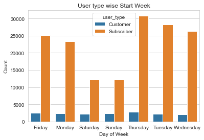

```python
sb.countplot(data=df_clean, x='start_time_weekday', hue='user_type');
plt.xlabel('Day of Week');
plt.ylabel('Count');
plt.title('User type wise Start Week');
```

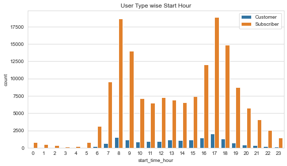

```python
plt.figure(figsize = [20, 5])

# left plot: clustered bar chart, absolute counts
plt.subplot(1, 2, 1)
sb.countplot(data = df_clean, x = 'start_time_hour', hue = 'user_type')
plt.legend();
plt.title('User Type wise Start Hour');
```

> **Subscribers take trips mostly during 8-9 am and 4-6 pm which is usually working hours of a company.**

## Trip Duration and Age

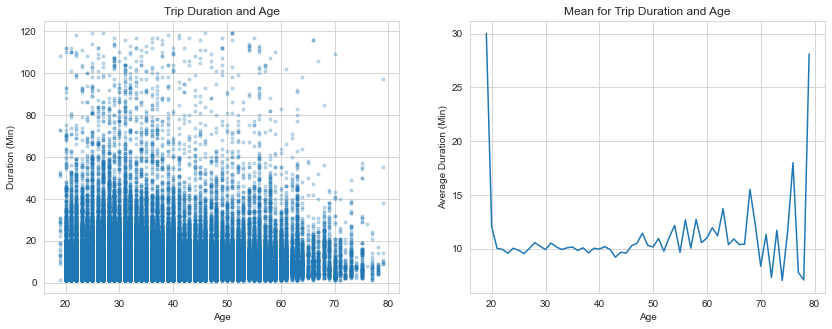

```python
plt.figure(figsize=[14,5]);
#plot scatter without the mean
plt.subplot(1, 2, 1)
plt.scatter(data = df,x ='User_age', y ='duration_min', alpha = 0.25, marker = '.' )
plt.title('Trip Duration and Age')
plt.xlabel('Age')
plt.ylabel('Duration (Min)')

# lineplot with the mean of trip_duration
plt.subplot(1, 2, 2)
mean_trip_duration= df.groupby('User_age')['duration_min'].mean().reset_index()
plt.errorbar(data = mean_trip_duration, x = 'User_age', y = 'duration_min');
plt.title('Mean for Trip Duration and Age')
plt.xlabel('Age')
plt.ylabel('Average Duration (Min)');
```

> **Even when I used the mean for trip duration, we can see that there is no apparent link between the two variables. However, there is a connection for persons above the age of 76 and below the age of 24.**

## Multivariate Exploration

> **Lets investigate and explore relationships between multiple variables.**

```python
# groupby Day, Gender and User Type by size
day_gen_typ = df_clean.groupby(['start_time_weekday', 'member_gender', 'user_type']).size().reset_index(name='count')
#pivot to rearrange the grouped data
day_gen_typ = day_gen_typ.pivot(index = 'start_time_weekday', columns = ['member_gender', 'user_type'], values = 'count')

# groupby Hour, Gender and User Type by size
hr_gen_typ = df_clean.groupby(['start_time_hour', 'member_gender', 'user_type']).size().reset_index(name='count')
#pivot to rearrange the grouped data
hr_gen_typ = hr_gen_typ.pivot(index = 'start_time_hour', columns = ['member_gender', 'user_type'], values = 'count')
```

## Is there relationship across males, females and others?

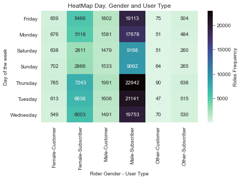

```python
# set figure size
plt.figure(figsize=(15,4))

# plot heatmap Day, Gender and User Type
plt.subplot(1,2,1)
sb.heatmap(day_gen_typ.dropna(), annot = True, fmt = 'd', cmap = 'mako_r', cbar_kws={'label': 'Rides Frequency'})

# set title and label
plt.title('HeatMap Day, Gender and User Type')
plt.xlabel('Rider Gender - User Type')
plt.ylabel('Day of the week')
```

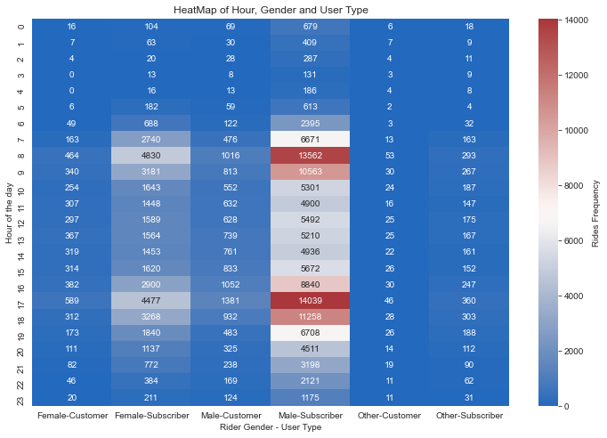

```python
# set figure size
plt.figure(figsize=(12,8))

# plot heatmap Month, Gender and User Type
sb.heatmap(hr_gen_typ.dropna(), annot = True, fmt = '.0f', cmap = 'vlag', cbar_kws={'label': 'Rides Frequency'})

# set title and label
plt.title('HeatMap of Hour, Gender and User Type')
plt.xlabel('Rider Gender - User Type')
plt.ylabel('Hour of the day');
```

```python
# groupby Day, Gender and User Type by avg duration
day_ride = df_clean.groupby(['start_time_weekday', 'member_gender', 'user_type']).mean().duration_sec.reset_index()

# groupby Hour, Gender and User Type by avg duration
hour_ride = df_clean.groupby(['start_time_hour', 'member_gender', 'user_type']).mean().duration_sec.reset_index()
```

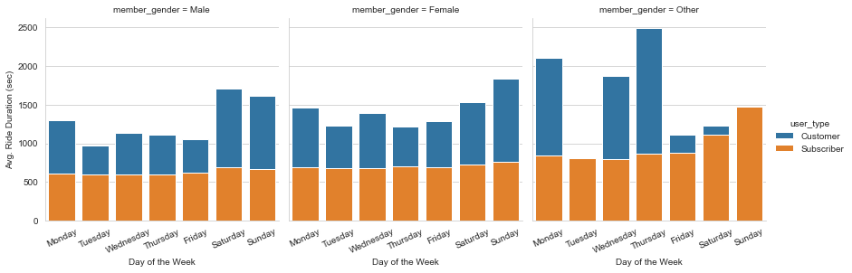

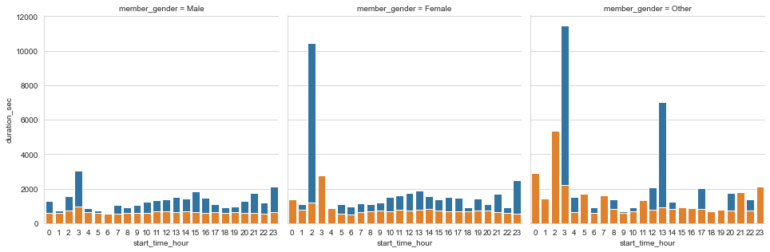

```python
weekday_order = ['Monday','Tuesday', 'Wednesday', 'Thursday', 'Friday', 'Saturday', 'Sunday']
hour_order = np.arange(0,24)

# plot the day_ride relationship using facegrid
g = sb.FacetGrid(data=day_ride, col='member_gender', hue='user_type', col_order = ['Male','Female','Other'], height=4)
g.map(sb.barplot, 'start_time_weekday', 'duration_sec', order=weekday_order);

# set plot properties
g.set_xticklabels(weekday_order, rotation=25)
g.set_axis_labels("Day of the Week", "Avg. Ride Duration (sec)")
g.add_legend()

# plot the day_ride relationship using facegrid
i = sb.FacetGrid(data=hour_ride, col='member_gender', hue='user_type', col_order = ['Male','Female','Other'], height=4.5)
i.map(sb.barplot, 'start_time_hour', 'duration_sec', order=hour_order)
```

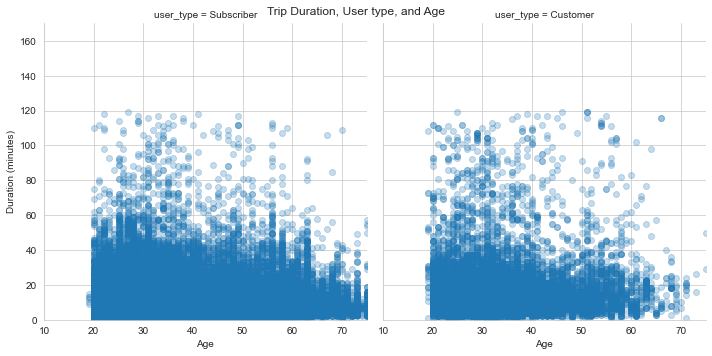

```python
# draw scatter for Trip Duration, User type, and Age
user_type = sns.FacetGrid(data = df, col = 'user_type', col_wrap = 2, height = 5,
                 xlim = [10, 75], ylim = [0, 170])
user_type.map(plt.scatter, 'User_age', 'duration_min', alpha= 0.25)
user_type.set_xlabels('Age')
user_type.set_ylabels('Duration (minutes)')
user_type.fig.suptitle('Trip Duration, User type, and Age')
plt.show()
```

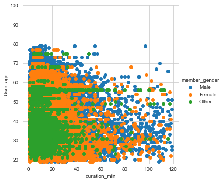

```python
g = sb.FacetGrid(data = df, hue = 'member_gender', height = 5)
g.map(plt.scatter, 'duration_min', 'User_age')
g.add_legend()
plt.ylim((18,100));
```